# Public support for welfare and redistributive policies in Ireland

Annex 1: Additional analyses

# 1 Introduction

This annex contains additional analyses that were either mentioned in the main report or provide supplementary results to the ones presented in the document.

# 2 Support for redistribution

## 2.1 Complete output table

The report includes a table with the coefficients of a logistic regression model explaining support for redistribution. The table ommits the effects for specific variables to facilitate reading. Table 1 shows all variables included in the model.

Table 1: Logistic regression coefficients (odds-ratio) for ‘support for redistribution’ (all variables), Ireland, 2003-2023

| **Characteristic** | **OR** | **95% CI** | **p-value** |
| --- | --- | --- | --- |
| Age group |  |  |  |
| 18-24 | — | — |  |
| 25-35 | 1.17 | 1.01, 1.35 | 0.036 |
| 36-45 | 1.14 | 0.98, 1.33 | 0.080 |
| 46-55 | 1.15 | 0.99, 1.34 | 0.072 |
| 56-65 | 1.63 | 1.38, 1.92 | <0.001 |
| >66 | 1.37 | 1.12, 1.67 | 0.002 |
| Gender |  |  |  |
| Male | — | — |  |
| Female | 1.11 | 1.03, 1.19 | 0.006 |
| Born in country |  |  |  |
| Yes | — | — |  |
| No | 0.81 | 0.73, 0.89 | <0.001 |
| Highest level of education, ES - ISCED | 0.96 | 0.95, 0.98 | <0.001 |
| Final Oesch class position - 5 classes |  |  |  |
| Higher-grade service class | — | — |  |
| Lower-grade service class | 1.31 | 1.17, 1.47 | <0.001 |
| Small business owners | 1.08 | 0.96, 1.22 | 0.2 |
| Skilled workers | 1.45 | 1.31, 1.60 | <0.001 |
| Unskilled workers | 1.87 | 1.66, 2.11 | <0.001 |
| Financial situation |  |  |  |
| Living comfortably on present income | — | — |  |
| Coping on present income | 1.35 | 1.25, 1.46 | <0.001 |
| Difficult on present income | 1.60 | 1.42, 1.80 | <0.001 |
| Very difficult on present income | 1.94 | 1.59, 2.37 | <0.001 |
| No answer | 3.44 | 1.30, 12.2 | 0.026 |
| Refusal | 0.80 | 0.33, 2.09 | 0.6 |
| Don't know | 0.79 | 0.51, 1.22 | 0.3 |
| as_factor(mnactic) |  |  |  |
| Paid work | — | — |  |
| Education | 0.92 | 0.78, 1.09 | 0.3 |
| Unemployed, looking for job | 0.88 | 0.75, 1.03 | 0.12 |
| Unemployed, not looking for job | 0.83 | 0.63, 1.09 | 0.2 |
| Permanently sick or disabled | 0.91 | 0.72, 1.16 | 0.4 |
| Retired | 0.97 | 0.83, 1.14 | 0.7 |
| Community or military service | 1.33 | 0.42, 5.70 | 0.7 |
| Housework, looking after children, others | 1.09 | 0.97, 1.23 | 0.14 |
| Other | 1.22 | 0.86, 1.75 | 0.3 |
| No answer | 1.49 | 0.76, 3.14 | 0.3 |
| Refusal | 25,605 | 0.10, | >0.9 |
| Don't know | 0.00 |  | >0.9 |
| Placement on left right scale | 0.90 | 0.88, 0.92 | <0.001 |
| as_factor(essround) |  |  |  |
| 1 | — | — |  |
| 2 | 0.80 | 0.68, 0.93 | 0.005 |
| 3 | 0.69 | 0.58, 0.82 | <0.001 |
| 4 | 0.88 | 0.75, 1.04 | 0.13 |
| 5 | 1.25 | 1.05, 1.49 | 0.013 |
| 6 | 1.06 | 0.90, 1.26 | 0.5 |
| 7 | 1.08 | 0.91, 1.29 | 0.4 |
| 8 | 0.96 | 0.81, 1.14 | 0.6 |
| 9 | 1.03 | 0.87, 1.23 | 0.7 |
| 10 | 1.17 | 0.96, 1.43 | 0.12 |
| 11 | 1.18 | 0.98, 1.41 | 0.083 |

Abbreviations: CI = Confidence Interval, OR = Odds Ratio  
Source: European Social SurveySource: European Social Survey

## 2.2 Original outcome variable (5-point)

The main outcome variable in the report is measured through the grouping of “Strongly agree” and “Agree” options for the statement that “Government should reduce income differences”. Here in Table 2, we show the results of an OLS model using the same independent variables and the outcome variable in their original format (5-point scale).

Table 2: OLS regression coefficients for ‘support for redistribution’ (original variable), Ireland, 2003-2023

| **Characteristic** | **Beta** | **95% CI** | **p-value** |
| --- | --- | --- | --- |
| Age group |  |  |  |
| 18-24 | — | — |  |
| 25-35 | 0.08 | 0.02, 0.15 | 0.008 |
| 36-45 | 0.09 | 0.02, 0.15 | 0.008 |
| 46-55 | 0.06 | -0.01, 0.12 | 0.074 |
| 56-65 | 0.19 | 0.13, 0.26 | <0.001 |
| >66 | 0.15 | 0.07, 0.23 | <0.001 |
| Gender |  |  |  |
| Male | — | — |  |
| Female | 0.05 | 0.02, 0.08 | 0.002 |
| Born in country |  |  |  |
| Yes | — | — |  |
| No | -0.10 | -0.14, -0.06 | <0.001 |
| Highest level of education, ES - ISCED | -0.02 | -0.02, -0.01 | <0.001 |
| Final Oesch class position - 5 classes |  |  |  |
| Higher-grade service class | — | — |  |
| Lower-grade service class | 0.14 | 0.09, 0.19 | <0.001 |
| Small business owners | 0.06 | 0.00, 0.11 | 0.037 |
| Skilled workers | 0.20 | 0.16, 0.25 | <0.001 |
| Unskilled workers | 0.27 | 0.23, 0.32 | <0.001 |
| Financial situation |  |  |  |
| Living comfortably on present income | — | — |  |
| Coping on present income | 0.16 | 0.12, 0.19 | <0.001 |
| Difficult on present income | 0.26 | 0.21, 0.31 | <0.001 |
| Very difficult on present income | 0.42 | 0.35, 0.49 | <0.001 |
| No answer | 0.50 | 0.17, 0.84 | 0.003 |
| Refusal | -0.01 | -0.40, 0.39 | >0.9 |
| Don't know | 0.01 | -0.20, 0.21 | >0.9 |
| as_factor(mnactic) |  |  |  |
| Paid work | — | — |  |
| Education | 0.00 | -0.07, 0.07 | >0.9 |
| Unemployed, looking for job | -0.02 | -0.09, 0.04 | 0.5 |
| Unemployed, not looking for job | -0.01 | -0.12, 0.10 | 0.9 |
| Permanently sick or disabled | 0.06 | -0.03, 0.15 | 0.2 |
| Retired | -0.01 | -0.07, 0.05 | 0.7 |
| Community or military service | 0.15 | -0.32, 0.62 | 0.5 |
| Housework, looking after children, others | 0.03 | -0.02, 0.08 | 0.2 |
| Other | 0.13 | -0.01, 0.27 | 0.072 |
| No answer | 0.12 | -0.16, 0.40 | 0.4 |
| Refusal | 0.17 | -0.82, 1.2 | 0.7 |
| Don't know | -1.7 | -3.0, -0.42 | 0.010 |
| Placement on left right scale | -0.06 | -0.06, -0.05 | <0.001 |
| as_factor(essround) |  |  |  |
| 1 | — | — |  |
| 2 | 0.01 | -0.06, 0.07 | 0.8 |
| 3 | -0.06 | -0.13, 0.01 | 0.10 |
| 4 | -0.01 | -0.08, 0.06 | 0.8 |
| 5 | 0.23 | 0.16, 0.31 | <0.001 |
| 6 | 0.19 | 0.12, 0.26 | <0.001 |
| 7 | 0.18 | 0.11, 0.26 | <0.001 |
| 8 | 0.03 | -0.04, 0.10 | 0.3 |
| 9 | 0.09 | 0.01, 0.16 | 0.019 |
| 10 | 0.15 | 0.07, 0.23 | <0.001 |
| 11 | 0.20 | 0.13, 0.28 | <0.001 |

Abbreviation: CI = Confidence Interval  
Source: European Social SurveySource: European Social Survey

## 2.3 Other countries

Table 3 below shows the results of the same model reported in Table 2 using pooled data from all other ESS countries (excluding Ireland).

Table 3: OLS regression coefficients for ‘support for redistribution’ (original variable), ESS countries without Ireland, 2003-2023

| **Characteristic** | **Beta** | **95% CI** | **p-value** |
| --- | --- | --- | --- |
| Age group |  |  |  |
| 18-24 | — | — |  |
| 25-35 | 0.08 | 0.06, 0.09 | <0.001 |
| 36-45 | 0.08 | 0.06, 0.10 | <0.001 |
| 46-55 | 0.13 | 0.11, 0.14 | <0.001 |
| 56-65 | 0.17 | 0.15, 0.18 | <0.001 |
| >66 | 0.18 | 0.16, 0.21 | <0.001 |
| Gender |  |  |  |
| Male | — | — |  |
| Female | 0.10 | 0.09, 0.11 | <0.001 |
| Born in country |  |  |  |
| Yes | — | — |  |
| No | -0.07 | -0.08, -0.06 | <0.001 |
| Highest level of education, ES - ISCED | -0.01 | -0.01, -0.01 | <0.001 |
| Final Oesch class position - 5 classes |  |  |  |
| Higher-grade service class | — | — |  |
| Lower-grade service class | 0.15 | 0.14, 0.16 | <0.001 |
| Small business owners | 0.10 | 0.09, 0.11 | <0.001 |
| Skilled workers | 0.25 | 0.23, 0.26 | <0.001 |
| Unskilled workers | 0.26 | 0.25, 0.27 | <0.001 |
| Financial situation |  |  |  |
| Living comfortably on present income | — | — |  |
| Coping on present income | 0.18 | 0.17, 0.19 | <0.001 |
| Difficult on present income | 0.31 | 0.29, 0.32 | <0.001 |
| Very difficult on present income | 0.39 | 0.37, 0.41 | <0.001 |
| Don't know | 0.09 | 0.02, 0.17 | 0.009 |
| Refusal | 0.08 | 0.00, 0.16 | 0.050 |
| No answer | 0.14 | 0.00, 0.28 | 0.057 |
| as_factor(mnactic) |  |  |  |
| Paid work | — | — |  |

[output cut: 59 more lines]

Abbreviation: CI = Confidence Interval  
Source: European Social SurveySource: European Social Survey

## 2.4 Household income as predictor

In the logistic regression model included in the report one of the SES measures is “feeling about the household income”. This variable is used as alternative to household income due to the low response rate for this variable. Table 4 below replaces the subjective measure with the household income deciles as measured in the survey (hinctnta).

Table 4: Logistic regression coefficients (odds-ratio) for ‘support for redistribution’ (household income), Ireland, 2003-2023

| **Characteristic** | **OR** | **95% CI** | **p-value** |
| --- | --- | --- | --- |
| Age group |  |  |  |
| 18-24 | — | — |  |
| 25-35 | 1.28 | 1.03, 1.59 | 0.023 |
| 36-45 | 1.29 | 1.03, 1.60 | 0.025 |
| 46-55 | 1.21 | 0.97, 1.51 | 0.095 |
| 56-65 | 1.77 | 1.39, 2.25 | <0.001 |
| >66 | 1.49 | 1.12, 1.99 | 0.006 |
| Gender |  |  |  |
| Male | — | — |  |
| Female | 1.08 | 0.98, 1.19 | 0.14 |
| Born in country |  |  |  |
| Yes | — | — |  |
| No | 0.81 | 0.71, 0.91 | <0.001 |
| Highest level of education, ES - ISCED | 0.98 | 0.96, 1.00 | 0.035 |
| Final Oesch class position - 5 classes |  |  |  |
| Higher-grade service class | — | — |  |
| Lower-grade service class | 1.29 | 1.11, 1.49 | <0.001 |
| Small business owners | 1.11 | 0.95, 1.31 | 0.2 |
| Skilled workers | 1.42 | 1.24, 1.63 | <0.001 |
| Unskilled workers | 1.89 | 1.60, 2.22 | <0.001 |
| as_factor(mnactic) |  |  |  |
| Paid work | — | — |  |
| Education | 0.89 | 0.70, 1.15 | 0.4 |
| Unemployed, looking for job | 0.80 | 0.65, 0.97 | 0.024 |
| Unemployed, not looking for job | 0.80 | 0.57, 1.15 | 0.2 |
| Permanently sick or disabled | 0.88 | 0.65, 1.20 | 0.4 |
| Retired | 0.87 | 0.71, 1.08 | 0.2 |
| Community or military service | 1.30 | 0.39, 6.32 | 0.7 |
| Housework, looking after children, others | 1.18 | 1.00, 1.39 | 0.051 |
| Other | 1.00 | 0.64, 1.61 | >0.9 |
| No answer | 1.65 | 0.32, 19.4 | 0.6 |
| Refusal | 9,993 | 0.00, | >0.9 |
| Placement on left right scale | 0.91 | 0.89, 0.94 | <0.001 |
| as_factor(essround) |  |  |  |
| 4 | — | — |  |
| 5 | 1.19 | 0.98, 1.46 | 0.084 |
| 6 | 1.17 | 0.96, 1.41 | 0.12 |
| 7 | 1.33 | 1.09, 1.62 | 0.005 |
| 8 | 1.10 | 0.91, 1.34 | 0.3 |
| 9 | 1.09 | 0.89, 1.33 | 0.4 |
| 10 | 1.11 | 0.89, 1.39 | 0.4 |
| 11 | 1.22 | 0.99, 1.50 | 0.060 |
| Household's total net income, all sources | 0.92 | 0.90, 0.94 | <0.001 |

Abbreviations: CI = Confidence Interval, OR = Odds Ratio  
Source: European Social SurveySource: European Social Survey

## 2.5 Pandemic impact in Ireland, Great Britain and Germany

Figure 1: Proportion of support for redistribution by social class and personal impact of the pandemic, Ireland, Great Britain and Germany, 2021

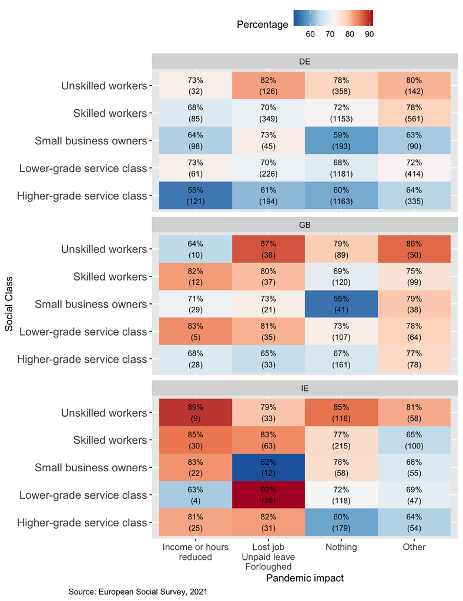